# Risk Factor Analysis

## Outcome Variable

**Outcome Variable:** ever_swasted

## Predictor Variables

**Intervention Variable:** impfloor

**Adjustment Set:**

unadjusted

## Stratifying Variables

The analysis was stratified on these variable(s):

- agecat
- studyid
- country

## Data Summary

| agecat | studyid | country | impfloor | ever_swasted | n_cell | n |
| --- | --- | --- | --- | --- | --- | --- |
| 0-24 months (no birth wast) | CMC-V-BCS-2002 | INDIA | 1 | 0 | 224 | 258 |
| 0-24 months (no birth wast) | CMC-V-BCS-2002 | INDIA | 1 | 1 | 34 | 258 |
| 0-24 months (no birth wast) | CMC-V-BCS-2002 | INDIA | 0 | 0 | 0 | 258 |
| 0-24 months (no birth wast) | CMC-V-BCS-2002 | INDIA | 0 | 1 | 0 | 258 |
| 0-24 months (no birth wast) | CONTENT | PERU | 1 | 0 | 200 | 215 |
| 0-24 months (no birth wast) | CONTENT | PERU | 1 | 1 | 1 | 215 |
| 0-24 months (no birth wast) | CONTENT | PERU | 0 | 0 | 14 | 215 |
| 0-24 months (no birth wast) | CONTENT | PERU | 0 | 1 | 0 | 215 |
| 0-24 months (no birth wast) | GMS-Nepal | NEPAL | 1 | 0 | 77 | 518 |
| 0-24 months (no birth wast) | GMS-Nepal | NEPAL | 1 | 1 | 16 | 518 |
| 0-24 months (no birth wast) | GMS-Nepal | NEPAL | 0 | 0 | 333 | 518 |
| 0-24 months (no birth wast) | GMS-Nepal | NEPAL | 0 | 1 | 92 | 518 |
| 0-24 months (no birth wast) | IRC | INDIA | 1 | 0 | 246 | 305 |
| 0-24 months (no birth wast) | IRC | INDIA | 1 | 1 | 59 | 305 |
| 0-24 months (no birth wast) | IRC | INDIA | 0 | 0 | 0 | 305 |
| 0-24 months (no birth wast) | IRC | INDIA | 0 | 1 | 0 | 305 |
| 0-24 months (no birth wast) | JiVitA-3 | BANGLADESH | 1 | 0 | 2038 | 26465 |
| 0-24 months (no birth wast) | JiVitA-3 | BANGLADESH | 1 | 1 | 49 | 26465 |
| 0-24 months (no birth wast) | JiVitA-3 | BANGLADESH | 0 | 0 | 23480 | 26465 |
| 0-24 months (no birth wast) | JiVitA-3 | BANGLADESH | 0 | 1 | 898 | 26465 |
| 0-24 months (no birth wast) | JiVitA-4 | BANGLADESH | 1 | 0 | 626 | 5380 |
| 0-24 months (no birth wast) | JiVitA-4 | BANGLADESH | 1 | 1 | 21 | 5380 |
| 0-24 months (no birth wast) | JiVitA-4 | BANGLADESH | 0 | 0 | 4523 | 5380 |
| 0-24 months (no birth wast) | JiVitA-4 | BANGLADESH | 0 | 1 | 210 | 5380 |
| 0-24 months (no birth wast) | MAL-ED | BANGLADESH | 1 | 0 | 212 | 242 |
| 0-24 months (no birth wast) | MAL-ED | BANGLADESH | 1 | 1 | 11 | 242 |
| 0-24 months (no birth wast) | MAL-ED | BANGLADESH | 0 | 0 | 18 | 242 |
| 0-24 months (no birth wast) | MAL-ED | BANGLADESH | 0 | 1 | 1 | 242 |
| 0-24 months (no birth wast) | MAL-ED | BRAZIL | 1 | 0 | 204 | 210 |
| 0-24 months (no birth wast) | MAL-ED | BRAZIL | 1 | 1 | 4 | 210 |

[output cut: 162 more lines]

The following strata were considered:

- agecat: 0-24 months (no birth wast), studyid: CMC-V-BCS-2002, country: INDIA
- agecat: 0-24 months (no birth wast), studyid: CONTENT, country: PERU
- agecat: 0-24 months (no birth wast), studyid: GMS-Nepal, country: NEPAL
- agecat: 0-24 months (no birth wast), studyid: IRC, country: INDIA
- agecat: 0-24 months (no birth wast), studyid: JiVitA-3, country: BANGLADESH
- agecat: 0-24 months (no birth wast), studyid: JiVitA-4, country: BANGLADESH
- agecat: 0-24 months (no birth wast), studyid: MAL-ED, country: BANGLADESH
- agecat: 0-24 months (no birth wast), studyid: MAL-ED, country: BRAZIL
- agecat: 0-24 months (no birth wast), studyid: MAL-ED, country: INDIA
- agecat: 0-24 months (no birth wast), studyid: MAL-ED, country: NEPAL
- agecat: 0-24 months (no birth wast), studyid: MAL-ED, country: PERU
- agecat: 0-24 months (no birth wast), studyid: MAL-ED, country: SOUTH AFRICA
- agecat: 0-24 months (no birth wast), studyid: MAL-ED, country: TANZANIA, UNITED REPUBLIC OF
- agecat: 0-24 months (no birth wast), studyid: NIH-Birth, country: BANGLADESH
- agecat: 0-24 months (no birth wast), studyid: NIH-Crypto, country: BANGLADESH
- agecat: 0-24 months (no birth wast), studyid: PROVIDE, country: BANGLADESH
- agecat: 0-6 months (no birth wast), studyid: CMC-V-BCS-2002, country: INDIA
- agecat: 0-6 months (no birth wast), studyid: CONTENT, country: PERU
- agecat: 0-6 months (no birth wast), studyid: GMS-Nepal, country: NEPAL
- agecat: 0-6 months (no birth wast), studyid: IRC, country: INDIA
- agecat: 0-6 months (no birth wast), studyid: JiVitA-3, country: BANGLADESH
- agecat: 0-6 months (no birth wast), studyid: JiVitA-4, country: BANGLADESH
- agecat: 0-6 months (no birth wast), studyid: MAL-ED, country: BANGLADESH
- agecat: 0-6 months (no birth wast), studyid: MAL-ED, country: BRAZIL
- agecat: 0-6 months (no birth wast), studyid: MAL-ED, country: INDIA
- agecat: 0-6 months (no birth wast), studyid: MAL-ED, country: NEPAL
- agecat: 0-6 months (no birth wast), studyid: MAL-ED, country: PERU
- agecat: 0-6 months (no birth wast), studyid: MAL-ED, country: SOUTH AFRICA
- agecat: 0-6 months (no birth wast), studyid: MAL-ED, country: TANZANIA, UNITED REPUBLIC OF
- agecat: 0-6 months (no birth wast), studyid: NIH-Birth, country: BANGLADESH
- agecat: 0-6 months (no birth wast), studyid: NIH-Crypto, country: BANGLADESH
- agecat: 0-6 months (no birth wast), studyid: PROVIDE, country: BANGLADESH
- agecat: 6-24 months, studyid: CMC-V-BCS-2002, country: INDIA
- agecat: 6-24 months, studyid: CONTENT, country: PERU
- agecat: 6-24 months, studyid: GMS-Nepal, country: NEPAL
- agecat: 6-24 months, studyid: IRC, country: INDIA
- agecat: 6-24 months, studyid: JiVitA-3, country: BANGLADESH
- agecat: 6-24 months, studyid: JiVitA-4, country: BANGLADESH
- agecat: 6-24 months, studyid: MAL-ED, country: BANGLADESH
- agecat: 6-24 months, studyid: MAL-ED, country: BRAZIL
- agecat: 6-24 months, studyid: MAL-ED, country: INDIA
- agecat: 6-24 months, studyid: MAL-ED, country: NEPAL
- agecat: 6-24 months, studyid: MAL-ED, country: PERU
- agecat: 6-24 months, studyid: MAL-ED, country: SOUTH AFRICA
- agecat: 6-24 months, studyid: MAL-ED, country: TANZANIA, UNITED REPUBLIC OF
- agecat: 6-24 months, studyid: NIH-Birth, country: BANGLADESH
- agecat: 6-24 months, studyid: NIH-Crypto, country: BANGLADESH
- agecat: 6-24 months, studyid: PROVIDE, country: BANGLADESH

### Dropped Strata

Some strata were dropped due to rare outcomes:

- agecat: 0-24 months (no birth wast), studyid: CMC-V-BCS-2002, country: INDIA
- agecat: 0-24 months (no birth wast), studyid: CONTENT, country: PERU
- agecat: 0-24 months (no birth wast), studyid: IRC, country: INDIA
- agecat: 0-24 months (no birth wast), studyid: MAL-ED, country: BANGLADESH
- agecat: 0-24 months (no birth wast), studyid: MAL-ED, country: BRAZIL
- agecat: 0-24 months (no birth wast), studyid: MAL-ED, country: INDIA
- agecat: 0-24 months (no birth wast), studyid: MAL-ED, country: NEPAL
- agecat: 0-24 months (no birth wast), studyid: MAL-ED, country: PERU
- agecat: 0-24 months (no birth wast), studyid: MAL-ED, country: SOUTH AFRICA
- agecat: 0-24 months (no birth wast), studyid: MAL-ED, country: TANZANIA, UNITED REPUBLIC OF
- agecat: 0-24 months (no birth wast), studyid: NIH-Crypto, country: BANGLADESH
- agecat: 0-6 months (no birth wast), studyid: CMC-V-BCS-2002, country: INDIA
- agecat: 0-6 months (no birth wast), studyid: CONTENT, country: PERU
- agecat: 0-6 months (no birth wast), studyid: IRC, country: INDIA
- agecat: 0-6 months (no birth wast), studyid: JiVitA-4, country: BANGLADESH
- agecat: 0-6 months (no birth wast), studyid: MAL-ED, country: BANGLADESH
- agecat: 0-6 months (no birth wast), studyid: MAL-ED, country: BRAZIL
- agecat: 0-6 months (no birth wast), studyid: MAL-ED, country: INDIA
- agecat: 0-6 months (no birth wast), studyid: MAL-ED, country: NEPAL
- agecat: 0-6 months (no birth wast), studyid: MAL-ED, country: PERU
- agecat: 0-6 months (no birth wast), studyid: MAL-ED, country: SOUTH AFRICA
- agecat: 0-6 months (no birth wast), studyid: MAL-ED, country: TANZANIA, UNITED REPUBLIC OF
- agecat: 0-6 months (no birth wast), studyid: NIH-Birth, country: BANGLADESH
- agecat: 0-6 months (no birth wast), studyid: NIH-Crypto, country: BANGLADESH
- agecat: 0-6 months (no birth wast), studyid: PROVIDE, country: BANGLADESH
- agecat: 6-24 months, studyid: CMC-V-BCS-2002, country: INDIA
- agecat: 6-24 months, studyid: CONTENT, country: PERU
- agecat: 6-24 months, studyid: IRC, country: INDIA
- agecat: 6-24 months, studyid: MAL-ED, country: BANGLADESH
- agecat: 6-24 months, studyid: MAL-ED, country: BRAZIL
- agecat: 6-24 months, studyid: MAL-ED, country: INDIA
- agecat: 6-24 months, studyid: MAL-ED, country: NEPAL
- agecat: 6-24 months, studyid: MAL-ED, country: PERU
- agecat: 6-24 months, studyid: MAL-ED, country: SOUTH AFRICA
- agecat: 6-24 months, studyid: MAL-ED, country: TANZANIA, UNITED REPUBLIC OF
- agecat: 6-24 months, studyid: NIH-Crypto, country: BANGLADESH
- agecat: 6-24 months, studyid: PROVIDE, country: BANGLADESH

## Methods Detail

We’re interested in the causal parameters $E[Y_a]$ for all values of $a \in \mathcal{A}$. These parameters represent the mean outcome if, possibly contrary to fact, we intervened to set all units to have $A=a$. Under the randomization and positivity assumptions, these are identified by the statistical parameters $\psi_a=E_W[E_{Y|A,W}(Y|A=a,W)]$. In addition, we’re interested in the mean of $Y$, $E[Y]$ under no intervention (the observed mean). We will estimate these parameters by using SuperLearner to fit the relevant likelihood factors – $E_{Y|A,W}(Y|A=a,W)$ and $p(A=a|W)$, and then updating our likelihood fit using a joint TMLE.

For unadjusted analyses ($W=\{\}$), initial likelihoods were estimated using Lrnr_glm to estimate the simple $E(Y|A)$ and Lrnr_mean to estimate $p(A)$. For adjusted analyses, a small library containing Lrnr_glmnet, Lrnr_xgboost, and Lrnr_mean was used.

Having estimated these parameters, we will then use the delta method to estimate relative risks and attributable risks relative to a prespecified baseline level of $A$.

# Results Detail

## Results Plots

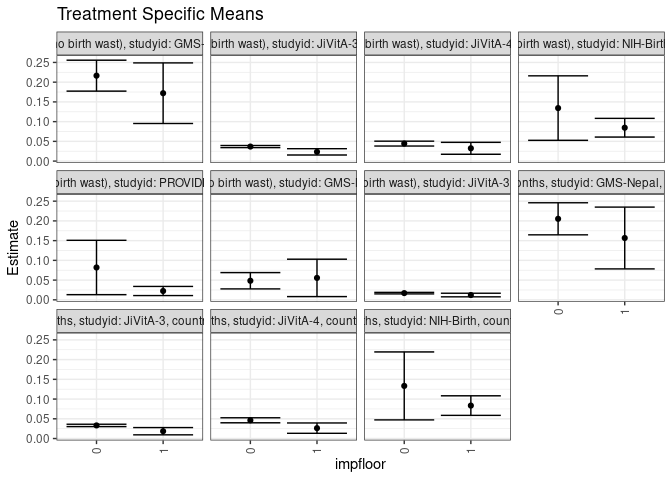

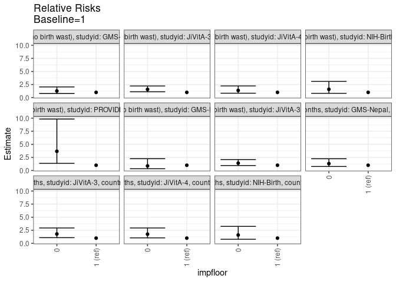

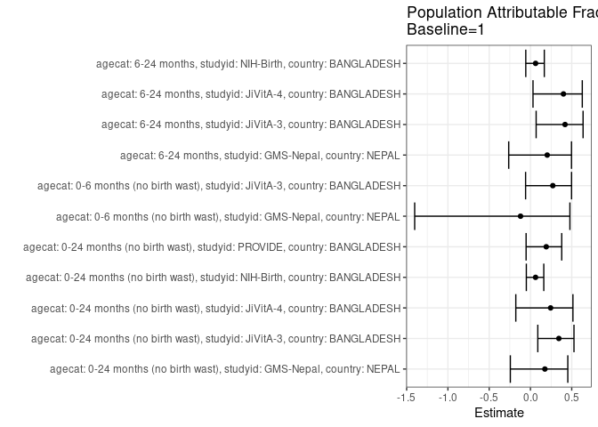

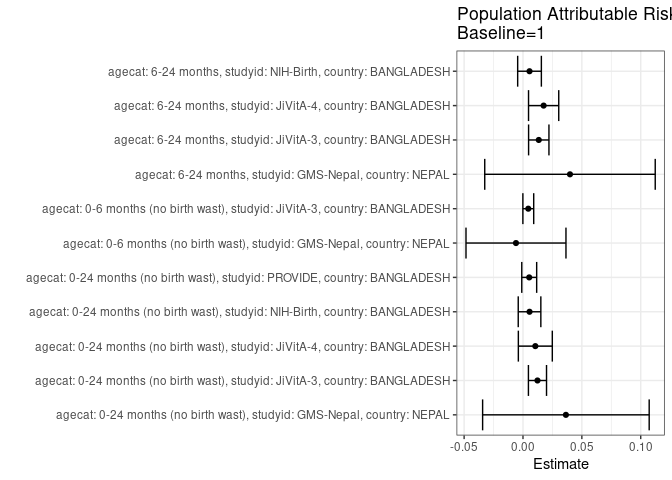

## Results Table

### Parameter: TSM

| agecat | studyid | country | intervention_level | baseline_level | estimate | ci_lower | ci_upper |
| --- | --- | --- | --- | --- | --- | --- | --- |
| 0-24 months (no birth wast) | GMS-Nepal | NEPAL | 1 | NA | 0.1720430 | 0.0952629 | 0.2488231 |
| 0-24 months (no birth wast) | GMS-Nepal | NEPAL | 0 | NA | 0.2164706 | 0.1772783 | 0.2556629 |
| 0-24 months (no birth wast) | JiVitA-3 | BANGLADESH | 1 | NA | 0.0234787 | 0.0154731 | 0.0314842 |
| 0-24 months (no birth wast) | JiVitA-3 | BANGLADESH | 0 | NA | 0.0368365 | 0.0341430 | 0.0395300 |
| 0-24 months (no birth wast) | JiVitA-4 | BANGLADESH | 1 | NA | 0.0324575 | 0.0173514 | 0.0475636 |
| 0-24 months (no birth wast) | JiVitA-4 | BANGLADESH | 0 | NA | 0.0443693 | 0.0381984 | 0.0505403 |
| 0-24 months (no birth wast) | NIH-Birth | BANGLADESH | 1 | NA | 0.0845865 | 0.0609210 | 0.1082519 |
| 0-24 months (no birth wast) | NIH-Birth | BANGLADESH | 0 | NA | 0.1343284 | 0.0526073 | 0.2160494 |
| 0-24 months (no birth wast) | PROVIDE | BANGLADESH | 1 | NA | 0.0223642 | 0.0107726 | 0.0339558 |
| 0-24 months (no birth wast) | PROVIDE | BANGLADESH | 0 | NA | 0.0819672 | 0.0130784 | 0.1508560 |
| 0-6 months (no birth wast) | GMS-Nepal | NEPAL | 1 | NA | 0.0555556 | 0.0081848 | 0.1029263 |
| 0-6 months (no birth wast) | GMS-Nepal | NEPAL | 0 | NA | 0.0483092 | 0.0276343 | 0.0689840 |
| 0-6 months (no birth wast) | JiVitA-3 | BANGLADESH | 1 | NA | 0.0121183 | 0.0075386 | 0.0166979 |
| 0-6 months (no birth wast) | JiVitA-3 | BANGLADESH | 0 | NA | 0.0170068 | 0.0150654 | 0.0189482 |
| 6-24 months | GMS-Nepal | NEPAL | 1 | NA | 0.1566265 | 0.0783519 | 0.2349012 |
| 6-24 months | GMS-Nepal | NEPAL | 0 | NA | 0.2052632 | 0.1646101 | 0.2459162 |
| 6-24 months | JiVitA-3 | BANGLADESH | 1 | NA | 0.0185800 | 0.0093769 | 0.0277831 |
| 6-24 months | JiVitA-3 | BANGLADESH | 0 | NA | 0.0332656 | 0.0302843 | 0.0362469 |
| 6-24 months | JiVitA-4 | BANGLADESH | 1 | NA | 0.0263566 | 0.0132651 | 0.0394481 |
| 6-24 months | JiVitA-4 | BANGLADESH | 0 | NA | 0.0462633 | 0.0399117 | 0.0526150 |
| 6-24 months | NIH-Birth | BANGLADESH | 1 | NA | 0.0835073 | 0.0587097 | 0.1083049 |
| 6-24 months | NIH-Birth | BANGLADESH | 0 | NA | 0.1333333 | 0.0472397 | 0.2194270 |

### Parameter: E(Y)

| agecat | studyid | country | intervention_level | baseline_level | estimate | ci_lower | ci_upper |
| --- | --- | --- | --- | --- | --- | --- | --- |
| 0-24 months (no birth wast) | GMS-Nepal | NEPAL | NA | NA | 0.2084942 | 0.1734774 | 0.2435110 |
| 0-24 months (no birth wast) | JiVitA-3 | BANGLADESH | NA | NA | 0.0357831 | 0.0332025 | 0.0383637 |
| 0-24 months (no birth wast) | JiVitA-4 | BANGLADESH | NA | NA | 0.0429368 | 0.0372250 | 0.0486486 |
| 0-24 months (no birth wast) | NIH-Birth | BANGLADESH | NA | NA | 0.0901503 | 0.0671959 | 0.1131046 |
| 0-24 months (no birth wast) | PROVIDE | BANGLADESH | NA | NA | 0.0276565 | 0.0153851 | 0.0399279 |
| 0-6 months (no birth wast) | GMS-Nepal | NEPAL | NA | NA | 0.0496032 | 0.0306286 | 0.0685777 |
| 0-6 months (no birth wast) | JiVitA-3 | BANGLADESH | NA | NA | 0.0166215 | 0.0148026 | 0.0184403 |
| 6-24 months | GMS-Nepal | NEPAL | NA | NA | 0.1965443 | 0.1603084 | 0.2327801 |
| 6-24 months | JiVitA-3 | BANGLADESH | NA | NA | 0.0319833 | 0.0290874 | 0.0348792 |
| 6-24 months | JiVitA-4 | BANGLADESH | NA | NA | 0.0438952 | 0.0380697 | 0.0497208 |
| 6-24 months | NIH-Birth | BANGLADESH | NA | NA | 0.0890538 | 0.0649864 | 0.1131212 |

### Parameter: RR

| agecat | studyid | country | intervention_level | baseline_level | estimate | ci_lower | ci_upper |
| --- | --- | --- | --- | --- | --- | --- | --- |
| 0-24 months (no birth wast) | GMS-Nepal | NEPAL | 1 | 1 | 1.0000000 | 1.0000000 | 1.000000 |
| 0-24 months (no birth wast) | GMS-Nepal | NEPAL | 0 | 1 | 1.2582353 | 0.7773218 | 2.036680 |
| 0-24 months (no birth wast) | JiVitA-3 | BANGLADESH | 1 | 1 | 1.0000000 | 1.0000000 | 1.000000 |
| 0-24 months (no birth wast) | JiVitA-3 | BANGLADESH | 0 | 1 | 1.5689338 | 1.1101972 | 2.217222 |
| 0-24 months (no birth wast) | JiVitA-4 | BANGLADESH | 1 | 1 | 1.0000000 | 1.0000000 | 1.000000 |
| 0-24 months (no birth wast) | JiVitA-4 | BANGLADESH | 0 | 1 | 1.3669977 | 0.8394998 | 2.225948 |
| 0-24 months (no birth wast) | NIH-Birth | BANGLADESH | 1 | 1 | 1.0000000 | 1.0000000 | 1.000000 |
| 0-24 months (no birth wast) | NIH-Birth | BANGLADESH | 0 | 1 | 1.5880597 | 0.8129350 | 3.102257 |
| 0-24 months (no birth wast) | PROVIDE | BANGLADESH | 1 | 1 | 1.0000000 | 1.0000000 | 1.000000 |
| 0-24 months (no birth wast) | PROVIDE | BANGLADESH | 0 | 1 | 3.6651054 | 1.3653919 | 9.838199 |
| 0-6 months (no birth wast) | GMS-Nepal | NEPAL | 1 | 1 | 1.0000000 | 1.0000000 | 1.000000 |
| 0-6 months (no birth wast) | GMS-Nepal | NEPAL | 0 | 1 | 0.8695652 | 0.3349377 | 2.257565 |
| 0-6 months (no birth wast) | JiVitA-3 | BANGLADESH | 1 | 1 | 1.0000000 | 1.0000000 | 1.000000 |
| 0-6 months (no birth wast) | JiVitA-3 | BANGLADESH | 0 | 1 | 1.4034014 | 0.9444311 | 2.085420 |
| 6-24 months | GMS-Nepal | NEPAL | 1 | 1 | 1.0000000 | 1.0000000 | 1.000000 |
| 6-24 months | GMS-Nepal | NEPAL | 0 | 1 | 1.3105263 | 0.7655670 | 2.243408 |
| 6-24 months | JiVitA-3 | BANGLADESH | 1 | 1 | 1.0000000 | 1.0000000 | 1.000000 |
| 6-24 months | JiVitA-3 | BANGLADESH | 0 | 1 | 1.7904030 | 1.0896521 | 2.941804 |
| 6-24 months | JiVitA-4 | BANGLADESH | 1 | 1 | 1.0000000 | 1.0000000 | 1.000000 |
| 6-24 months | JiVitA-4 | BANGLADESH | 0 | 1 | 1.7552857 | 1.0481491 | 2.939494 |
| 6-24 months | NIH-Birth | BANGLADESH | 1 | 1 | 1.0000000 | 1.0000000 | 1.000000 |
| 6-24 months | NIH-Birth | BANGLADESH | 0 | 1 | 1.5966667 | 0.7844330 | 3.249920 |

### Parameter: PAR

| agecat | studyid | country | intervention_level | baseline_level | estimate | ci_lower | ci_upper |
| --- | --- | --- | --- | --- | --- | --- | --- |
| 0-24 months (no birth wast) | GMS-Nepal | NEPAL | 1 | NA | 0.0364512 | -0.0342917 | 0.1071941 |
| 0-24 months (no birth wast) | JiVitA-3 | BANGLADESH | 1 | NA | 0.0123044 | 0.0046165 | 0.0199923 |
| 0-24 months (no birth wast) | JiVitA-4 | BANGLADESH | 1 | NA | 0.0104793 | -0.0039429 | 0.0249015 |
| 0-24 months (no birth wast) | NIH-Birth | BANGLADESH | 1 | NA | 0.0055638 | -0.0040351 | 0.0151627 |
| 0-24 months (no birth wast) | PROVIDE | BANGLADESH | 1 | NA | 0.0052923 | -0.0010389 | 0.0116234 |
| 0-6 months (no birth wast) | GMS-Nepal | NEPAL | 1 | NA | -0.0059524 | -0.0484094 | 0.0365046 |
| 0-6 months (no birth wast) | JiVitA-3 | BANGLADESH | 1 | NA | 0.0045032 | -0.0000964 | 0.0091027 |
| 6-24 months | GMS-Nepal | NEPAL | 1 | NA | 0.0399178 | -0.0324926 | 0.1123282 |
| 6-24 months | JiVitA-3 | BANGLADESH | 1 | NA | 0.0134034 | 0.0047624 | 0.0220443 |
| 6-24 months | JiVitA-4 | BANGLADESH | 1 | NA | 0.0175387 | 0.0047112 | 0.0303661 |
| 6-24 months | NIH-Birth | BANGLADESH | 1 | NA | 0.0055465 | -0.0045144 | 0.0156074 |

### Parameter: PAF

| agecat | studyid | country | intervention_level | baseline_level | estimate | ci_lower | ci_upper |
| --- | --- | --- | --- | --- | --- | --- | --- |
| 0-24 months (no birth wast) | GMS-Nepal | NEPAL | 1 | NA | 0.1748307 | -0.2437799 | 0.4525524 |
| 0-24 months (no birth wast) | JiVitA-3 | BANGLADESH | 1 | NA | 0.3438615 | 0.0891309 | 0.5273549 |
| 0-24 months (no birth wast) | JiVitA-4 | BANGLADESH | 1 | NA | 0.2440635 | -0.1774800 | 0.5146924 |
| 0-24 months (no birth wast) | NIH-Birth | BANGLADESH | 1 | NA | 0.0617168 | -0.0499751 | 0.1615274 |
| 0-24 months (no birth wast) | PROVIDE | BANGLADESH | 1 | NA | 0.1913570 | -0.0528139 | 0.3788993 |
| 0-6 months (no birth wast) | GMS-Nepal | NEPAL | 1 | NA | -0.1200000 | -1.4026764 | 0.4779156 |
| 0-6 months (no birth wast) | JiVitA-3 | BANGLADESH | 1 | NA | 0.2709256 | -0.0588840 | 0.4980097 |
| 6-24 months | GMS-Nepal | NEPAL | 1 | NA | 0.2030981 | -0.2634292 | 0.4973580 |
| 6-24 months | JiVitA-3 | BANGLADESH | 1 | NA | 0.4190733 | 0.0688883 | 0.6375560 |
| 6-24 months | JiVitA-4 | BANGLADESH | 1 | NA | 0.3995570 | 0.0309721 | 0.6279449 |
| 6-24 months | NIH-Birth | BANGLADESH | 1 | NA | 0.0622825 | -0.0566201 | 0.1678049 |